# Bayesian Linear Regression

庄亮亮

2020/11/10

```r
#devtools::install_github("julianfaraway/brinla") #可能要翻墙
library(INLA)
library(brinla)
library(ggplot2)
library(GGally)
library(tidyr)
library(MASS)
library(nlme)
```

# 1. Bayesian inference for linear regression

**空气污染数据**：调查美国41个城市污染的决定因素。以`SO2`作为因变量，其他六个变量作为潜在解释变量。

在这些潜在解释变量中，有两个与人类生态相关`(pop,manuf)`，另外四个与气候相关`(negtemp,wind,precip,days)`。变量`negtemp`表示年平均气温的负值。在这里使用负值是因为所有的变量都是这样的，高的值表示一个不太事宜的环境。

```r
data(usair, package = "brinla")
knitr::kable(head(usair),
             caption = 'usair数据',
             align='c')
```

usair数据

|  | SO2 | negtemp | manuf | pop | wind | precip | days |
| --- | --- | --- | --- | --- | --- | --- | --- |
| Phoenix | 10 | -70.3 | 213 | 582 | 6.0 | 7.05 | 36 |
| Little Rock | 13 | -61.0 | 91 | 132 | 8.2 | 48.52 | 100 |
| San Francisco | 12 | -56.7 | 453 | 716 | 8.7 | 20.66 | 67 |
| Denver | 17 | -51.9 | 454 | 515 | 9.0 | 12.95 | 86 |
| Hartford | 56 | -49.1 | 412 | 158 | 9.0 | 43.37 | 127 |
| Wilmington | 36 | -54.0 | 80 | 80 | 9.0 | 40.25 | 114 |

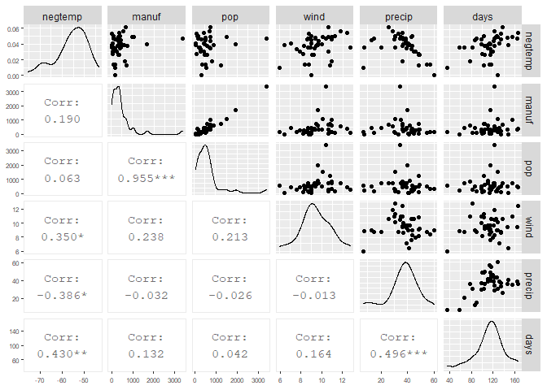

```r
pairs.chart <- ggpairs(usair[,-1], lower = list(continuous = "cor"), upper = list(continuous = "points", combo = "dot")) + ggplot2::theme(axis.text = element_text(size = 6))
pairs.chart
```

`Manuf`与`Pop`高度相关:`r=0.955`；我们在模型中只需保留一个。

## 1.1 Frequentist approach

```r
usair.formula1 <-  SO2 ~ negtemp + manuf + wind + precip + days
usair.lm1 <- lm(usair.formula1, data = usair)
knitr::kable(round(coef(summary(usair.lm1)), 4),
             caption = '拟合情况汇总',
             align='c')
```

拟合情况汇总

|  | Estimate | Std. Error | t value | Pr(>\|t\|) |
| --- | --- | --- | --- | --- |
| (Intercept) | 135.7714 | 50.0610 | 2.7121 | 0.0103 |
| negtemp | 1.7714 | 0.6366 | 2.7824 | 0.0086 |
| manuf | 0.0256 | 0.0046 | 5.5544 | 0.0000 |
| wind | -3.7379 | 1.9444 | -1.9224 | 0.0627 |
| precip | 0.6259 | 0.3885 | 1.6111 | 0.1161 |
| days | -0.0571 | 0.1748 | -0.3265 | 0.7460 |

结果表明，`negtemp`和`manuf`是重要的解释变量，而`wind`,`precip`和`days`不是。

- 标准残差

```r
round(summary(usair.lm1)$sigma, 4)
```

```
## [1] 15.79
```

## 1.2 Bayesian Regression with INLA

默认情况下：
$$\begin{equation*}
\beta_{j} \sim N\left(0,10^{6}\right), \quad j=0, \ldots, p
\end{equation*}$$

$$\begin{equation*}
\log (\tau) \sim \log \operatorname{Gamma}\left(1,10^{-5}\right)
\end{equation*}$$

```r
usair.inla1 <- inla(usair.formula1, data = usair, control.compute = list(dic = TRUE, cpo = TRUE))
```

```r
knitr::kable(round(usair.inla1$summary.fixed, 4),
             caption = '固定效应信息',
             align='c')
```

固定效应信息

|  | mean | sd | 0.025quant | 0.5quant | 0.975quant | mode | kld |
| --- | --- | --- | --- | --- | --- | --- | --- |
| (Intercept) | 135.4904 | 49.8882 | 36.9784 | 135.4963 | 233.8821 | 135.5120 | 0 |
| negtemp | 1.7690 | 0.6347 | 0.5157 | 1.7690 | 3.0209 | 1.7692 | 0 |
| manuf | 0.0256 | 0.0046 | 0.0165 | 0.0256 | 0.0346 | 0.0256 | 0 |
| wind | -3.7230 | 1.9357 | -7.5432 | -3.7234 | 0.0964 | -3.7241 | 0 |
| precip | 0.6249 | 0.3874 | -0.1401 | 0.6249 | 1.3890 | 0.6249 | 0 |
| days | -0.0567 | 0.1743 | -0.4007 | -0.0567 | 0.2872 | -0.0567 | 0 |

```r
knitr::kable(round(usair.inla1$summary.hyperpar, 4),
             caption = '超参数信息',
             align='c')
```

超参数信息

|  | mean | sd | 0.025quant | 0.5quant | 0.975quant | mode |
| --- | --- | --- | --- | --- | --- | --- |
| Precision for the Gaussian observations | 0.0042 | 0.001 | 0.0025 | 0.0042 | 0.0064 | 0.004 |

```r
summary(usair.inla1)
```

```
##
## Call:
##    c("inla(formula = usair.formula1, data = usair, control.compute =
##    list(dic = TRUE, ", " cpo = TRUE))")
## Time used:
##     Pre = 1.26, Running = 0.386, Post = 0.125, Total = 1.77
## Fixed effects:
##                mean     sd 0.025quant 0.5quant 0.975quant    mode kld
## (Intercept) 135.490 49.888     36.978  135.496    233.882 135.512   0
## negtemp       1.769  0.635      0.516    1.769      3.021   1.769   0
## manuf         0.026  0.005      0.017    0.026      0.035   0.026   0
## wind         -3.723  1.936     -7.543   -3.723      0.096  -3.724   0
## precip        0.625  0.387     -0.140    0.625      1.389   0.625   0
## days         -0.057  0.174     -0.401   -0.057      0.287  -0.057   0
##
## Model hyperparameters:
##                                          mean    sd 0.025quant 0.5quant
## Precision for the Gaussian observations 0.004 0.001      0.003    0.004
##                                         0.975quant  mode
## Precision for the Gaussian observations      0.006 0.004
##
## Expected number of effective parameters(stdev): 6.00(0.001)
## Number of equivalent replicates : 6.84
##
## Deviance Information Criterion (DIC) ...............: 350.76
## Deviance Information Criterion (DIC, saturated) ....: 51.32
## Effective number of parameters .....................: 7.21
##
## Marginal log-Likelihood:  -208.73
## CPO and PIT are computed
##
## Posterior marginals for the linear predictor and
##  the fitted values are computed
```

- 计算$\sigma$的后验估计值

默认情况下，inla对象输出的是后验信息的精确参数$\tau$。然而常常我们对后验均值$\sigma$感兴趣。

`bri.hyperpar.summary`用于生成超参数$\sigma$的汇总统计信息。

```r
knitr::kable(round(bri.hyperpar.summary(usair.inla1), 4),
             caption = '超参数信息',
             align='c')
```

超参数信息

|  | mean | sd | q0.025 | q0.5 | q0.975 | mode |
| --- | --- | --- | --- | --- | --- | --- |
| SD for the Gaussian observations | 15.67 | 1.865 | 12.53 | 15.49 | 19.84 | 15.14 |

- 绘制$\sigma$的后验密度

使用函数`bri.hyperpar.plot`。

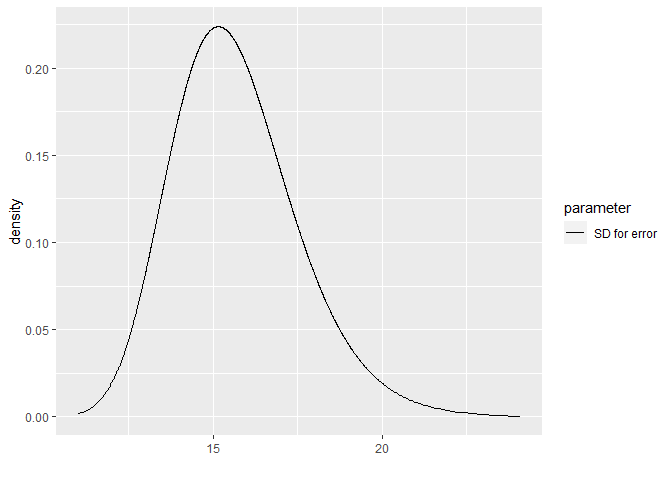

```r
bri.hyperpar.plot(usair.inla1)
```

$\sigma$有略微右偏的后验分布。

- 改变先验

假设 $\beta_0 \sim N(100,100)$, $\beta_{negtemp} \sim N(2,1)$ 和 $\beta_{wind} \sim N(−3,1)$。

如果想假设$\tau$服从对数正态分布(对数$\tau$服从正态分布)，可以使用选项`control.family`来指定。

```r
usair.inla2 <- inla(usair.formula1, data = usair, control.compute = list(dic = TRUE, cpo =TRUE),
    control.fixed = list(mean.intercept = 100, prec.intercept = 10^(-2), mean = list(negtemp = 2, wind = -3, default =0), prec = 1),
    control.family = list(hyper = list(prec = list(prior="gaussian", param =c(0,1)))))
summary(usair.inla2)
```

```
##
## Call:
##    c("inla(formula = usair.formula1, data = usair, control.compute =
##    list(dic = TRUE, ", " cpo = TRUE), control.family = list(hyper =
##    list(prec = list(prior = \"gaussian\", ", " param = c(0, 1)))),
##    control.fixed = list(mean.intercept = 100, ", " prec.intercept =
##    10^(-2), mean = list(negtemp = 2, wind = -3, ", " default = 0), prec =
##    1))")
## Time used:
##     Pre = 0.586, Running = 0.4, Post = 0.119, Total = 1.1
## Fixed effects:
##                mean    sd 0.025quant 0.5quant 0.975quant    mode kld
## (Intercept) 102.395 9.562     83.615  102.397    121.149 102.401   0
## negtemp       1.384 0.212      0.966    1.385      1.801   1.385   0
## manuf         0.025 0.004      0.018    0.025      0.033   0.025   0
## wind         -2.952 0.803     -4.529   -2.952     -1.376  -2.952   0
## precip        0.441 0.246     -0.045    0.441      0.925   0.442   0
## days          0.041 0.090     -0.136    0.040      0.218   0.040   0
##
## Model hyperparameters:
##                                          mean    sd 0.025quant 0.5quant
## Precision for the Gaussian observations 0.005 0.001      0.003    0.005
##                                         0.975quant  mode
## Precision for the Gaussian observations      0.008 0.005
##
## Expected number of effective parameters(stdev): 4.33(0.074)
## Number of equivalent replicates : 9.48
##
## Deviance Information Criterion (DIC) ...............: 347.57
## Deviance Information Criterion (DIC, saturated) ....: 57.38
## Effective number of parameters .....................: 5.26
##
## Marginal log-Likelihood:  -197.50
## CPO and PIT are computed
##
## Posterior marginals for the linear predictor and
##  the fitted values are computed
```

# 2. Prediction

## 2.1 The prediction in lm

```r
# new observations
new.data <- data.frame(
  negtemp = c(-50, -60, -40),
  manuf = c(150, 100, 400),
  pop = c(200, 100, 300),
  wind = c(6, 7, 8),
  precip = c(10, 30, 20),
  days = c(20, 100, 40))
knitr::kable(head(new.data))
```

| negtemp | manuf | pop | wind | precip | days |
| --- | --- | --- | --- | --- | --- |
| -50 | 150 | 200 | 6 | 10 | 20 |
| -60 | 100 | 100 | 7 | 30 | 100 |
| -40 | 400 | 300 | 8 | 20 | 40 |

```r
predict(usair.lm1, new.data, se.fit = TRUE)
```

```
## $fit
##     1     2     3
## 33.73 18.95 55.48
##
## $se.fit
##      1      2      3
## 14.937  5.329 17.639
##
## $df
## [1] 35
##
## $residual.scale
## [1] 15.79
```

输出：`预测向量(\$fit)`、`预测均值的标准误差向量(\$se.fit)`、`残差的自由度(\$df)`和`残差标准差($residual.scale)`。

## 2.2 The prediction in INLA

在INLA中，与lm的函数预测不同。预测可以作为模型拟合的一部分。由于预测和拟合一个有缺失数据的模型是一样的，我们需要设置响应变量`“y[i]=NA”`表示我们想要预测的值。

```r
usair.combined <- rbind(usair, data.frame(SO2 = c(NA, NA, NA), new.data))
knitr::kable(tail(usair.combined))
```

|  | SO2 | negtemp | manuf | pop | wind | precip | days |
| --- | --- | --- | --- | --- | --- | --- | --- |
| Seattle | 29 | -51.1 | 379 | 531 | 9.4 | 38.79 | 164 |
| Charleston | 31 | -55.2 | 35 | 71 | 6.5 | 40.75 | 148 |
| Milwaukee | 16 | -45.7 | 569 | 717 | 11.8 | 29.07 | 123 |
| 1 | NA | -50.0 | 150 | 200 | 6.0 | 10.00 | 20 |
| 2 | NA | -60.0 | 100 | 100 | 7.0 | 30.00 | 100 |
| 3 | NA | -40.0 | 400 | 300 | 8.0 | 20.00 | 40 |

```r
usair.link <- c(rep(NA, nrow(usair)), rep(1, nrow(new.data)))
tail(usair.link)
```

```
## [1] NA NA NA  1  1  1
```

```r
usair.inla1.pred <- inla(usair.formula1, data = usair.combined, control.predictor = list(link = usair.link))

knitr::kable(usair.inla1.pred$summary.fitted.values[(nrow(usair)+1):nrow(usair.combined),], caption = '拟合情况', align='c')
```

拟合情况

|  | mean | sd | 0.025quant | 0.5quant | 0.975quant | mode |
| --- | --- | --- | --- | --- | --- | --- |
| fitted.Predictor.42 | 33.65 | 14.88 | 4.316 | 33.66 | 63.00 | 33.66 |
| fitted.Predictor.43 | 18.93 | 5.31 | 8.461 | 18.93 | 29.40 | 18.93 |
| fitted.Predictor.44 | 55.41 | 17.58 | 20.753 | 55.41 | 90.07 | 55.41 |

# 3. Model selection and checking

## 3.1 DIC

- AIC

```r
usair.step <- stepAIC(usair.lm1, trace = FALSE)
usair.step$anova
```

```
## Stepwise Model Path
## Analysis of Deviance Table
##
## Initial Model:
## SO2 ~ negtemp + manuf + wind + precip + days
##
## Final Model:
## SO2 ~ negtemp + manuf + wind + precip
##
##
##     Step Df Deviance Resid. Df Resid. Dev   AIC
## 1                           35       8726 231.8
## 2 - days  1    26.57        36       8753 229.9
```

```r
# Final multiple regression model
usair.formula2 <- SO2 ~ negtemp + manuf + wind + precip
usair.lm2 <- lm(usair.formula2, data = usair)
knitr::kable(round(coef(summary(usair.lm2)), 4))
```

|  | Estimate | Std. Error | t value | Pr(>\|t\|) |
| --- | --- | --- | --- | --- |
| (Intercept) | 123.1183 | 31.2907 | 3.935 | 0.0004 |
| negtemp | 1.6114 | 0.4014 | 4.015 | 0.0003 |
| manuf | 0.0255 | 0.0045 | 5.615 | 0.0000 |
| wind | -3.6302 | 1.8923 | -1.918 | 0.0630 |
| precip | 0.5242 | 0.2294 | 2.285 | 0.0283 |

- DIC

在贝叶斯分析中，DIC是AIC的推广，是最常用的贝叶斯模型比较方法之一，定义为拟合优度度量和模型复杂度度量的总和

```r
usair.inla3 <- inla(usair.formula2, data = usair, control.compute = list(dic = TRUE, cpo = TRUE))
c(usair.inla1$dic$dic, usair.inla3$dic$dic)
```

```
## [1] 350.8 348.7
```

最佳模型：所有子集回归中最小的DIC。

## 3.2 Posterior Predictive Checking

在贝叶斯分析中，模型评估通常是

1. 基于后验预测检查；
2. 留一交叉验证预测检查。

### 3.2.1 基于后验预测检查

后验预测p值可以通过R函数`INLA .pmarginal`得到

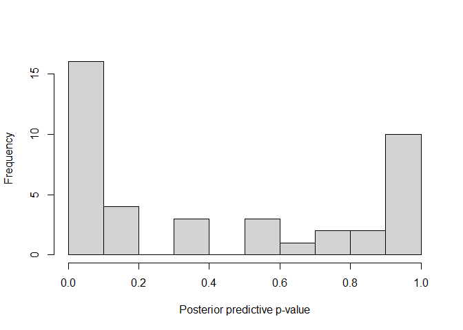

```r
usair.inla3.pred <- inla(usair.formula2, data = usair, control.predictor = list(link = 1, compute = TRUE))
post.predicted.pval <- vector(mode = "numeric", length = nrow(usair))
for(i in (1:nrow(usair))) {
  post.predicted.pval[i] <- inla.pmarginal(q=usair$SO2[i], marginal = usair.inla3.pred$marginals.fitted.values[[i]])
}
hist(post.predicted.pval, main="", breaks = 10, xlab="Posterior predictive p-value")
```

很多后验预测p值都接近于0或1。然而，解释后验预测p值的一个**缺点**是，即使数据来自真实的模型，它们也不能具有均匀分布。 因此，后验预测p值的图并不令人满意，我们希望使用其他模型评估方法进一步检验该模型。

### 3.2.2 留一交叉验证预测检查

评价模型的优劣的两个量：

1. conditional predictive ordinate (CPO)

$$CPO_{i} =p\left(y_{i} \mid y_{-i}\right)$$

2. probability integral transform (PIT)

$$\mathrm{PIT}_{i} =p\left(y_{i}^{*} \leq y_{i} \mid \mathbf{y}_{-i}\right)$$

在INLA中有针对潜在问题的内部检查，这些问题出现在`usair.inla3$cpo$failure`中。它是一个向量，每个观测值都包含0或1。当值为1时，表示CPO或PIT的估计对于相应的观测是不可靠的。在我们的例子中，我们可以通过以下方法检查是否存在故障：

```r
sum(usair.inla3$cpo$failure)
```

```
## [1] 0
```

因此，在`usair.inla3`中不存在CPOs和PITs的计算问题。

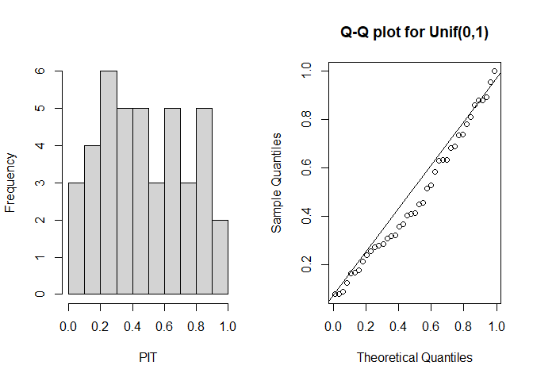

```r
par(mfrow = c(1, 2))
hist(usair.inla3$cpo$pit, main="", breaks = 10, xlab = "PIT")
qqplot(qunif(ppoints(length(usair.inla3$cpo$pit))), usair.inla3$cpo$pit, main = "Q-Q plot for Unif(0,1)", xlab = "Theoretical Quantiles", ylab = "Sample Quantiles")
qqline(usair.inla3$cpo$pit, distribution = function(p) qunif(p), prob = c(0.1, 0.9))
```

PITs的分布接近均匀分布，表明模型对数据的拟合较为合理。值得注意的是，PITs直方图比对应的后验预测直方图更接近均匀分布。

- Compare LPML for the full model and reduce model

如果我们把所有$CPO$值的乘积看作一个“伪边际似然”，这就给出了一个交叉验证的拟合度度量。Geisser和Eddy(1979)提出的对数拟边际似然($LPML$)：
$$L P M L=\log \left\{\prod_{i=1}^{n} p\left(y_{i} \mid \mathbf{y}_{-i}\right)\right\}=\sum_{i=1}^{n} \log p\left(y_{i} \mid \mathbf{y}_{-i}\right)=\sum_{i=1}^{n} \log \mathrm{CPO}_{i}$$

```r
LPML1 <- sum(log(usair.inla1$cpo$cpo))
LPML3 <- sum(log(usair.inla3$cpo$cpo))
c(LPML1, LPML3)
```

```
## [1] -177.4 -176.1
```

简化模型的LPML比完整模型的LPML大，这表明简化模型是首选的。

- CPOs的逐点比较

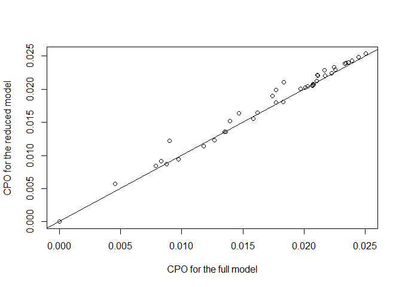

```r
par(mfrow=c(1,1))
plot(usair.inla1$cpo$cpo, usair.inla3$cpo$cpo, xlab="CPO for the full model", ylab="CPO for the reduced model")
abline(0,1)
```

CPO值表明模型拟合较好，参考线以上的点的优势意味着对简化模型的偏好。这与我们之前使用DIC和LPML标准的研究结果一致。

## 3.4 Bayesian residual plots

使用`bri.lmresid.plot`生成贝叶斯残差图:

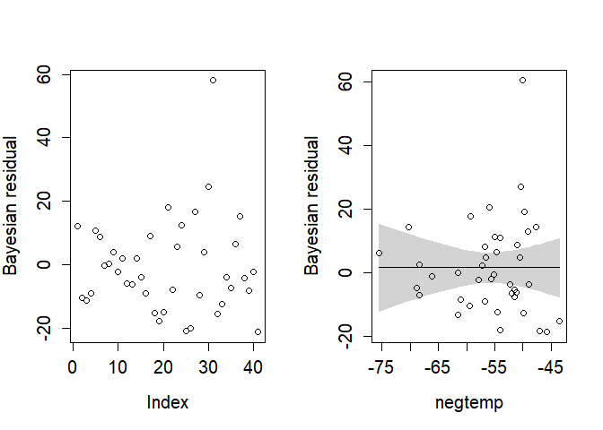

```r
par(mfrow=c(1,2))
bri.lmresid.plot(usair.inla3)
bri.lmresid.plot(usair.inla3, usair$negtemp, xlab = "negtemp", smooth =TRUE)
```

贝叶斯残差一般都在零附近呈现随机模式。但我们发现观测数31似乎是一个离群值，其贝叶斯残差高达59.6927。

# 4. Robust Linear regression with t-distribution

在INLA中，通过指定`family="T"`来实现。

```r
## Usair data example
usair.inla4 <- inla(usair.formula2, family = "T", data = usair, control.compute = list(dic = TRUE, cpo = TRUE))
# summary(usair.inla4)

knitr::kable(round(usair.inla4$summary.fixed, 4),caption = '固定效应情况', align='c')
```

固定效应情况

|  | mean | sd | 0.025quant | 0.5quant | 0.975quant | mode | kld |
| --- | --- | --- | --- | --- | --- | --- | --- |
| (Intercept) | 118.4034 | 26.0576 | 67.4027 | 118.2333 | 170.3176 | 117.9043 | 0 |
| negtemp | 1.4297 | 0.3447 | 0.7729 | 1.4216 | 2.1329 | 1.4051 | 0 |
| manuf | 0.0267 | 0.0036 | 0.0192 | 0.0268 | 0.0335 | 0.0270 | 0 |
| wind | -4.0148 | 1.5948 | -7.1428 | -4.0229 | -0.8415 | -4.0363 | 0 |
| precip | 0.4257 | 0.1909 | 0.0682 | 0.4186 | 0.8223 | 0.4038 | 0 |

```r
knitr::kable(round(usair.inla4$summary.hyperpar, 4), caption = '
    超参数情况', align='c')
```

超参数情况

|  | mean | sd | 0.025quant | 0.5quant | 0.975quant | mode |
| --- | --- | --- | --- | --- | --- | --- |
| precision for the student-t observations | 0.0053 | 0.0016 | 0.003 | 0.0051 | 0.0092 | 0.0046 |
| degrees of freedom for student-t | 10.9806 | 8.7815 | 3.567 | 8.3861 | 34.1006 | 5.6094 |

# 5. Analysis of Variance

下面的例子，我们将只关注**固定效应**的方差分析模型。关于随机效应模型，将在第5章详细介绍。

来自一项研究可待因和针灸对男性患者术后牙痛的影响的实验(Kutner等，2004年)。

该研究采用随机区组设计，在一个因子结构中出现两个治疗因素。两种治疗因素都有两个层次。

反应变量缓解是疼痛缓解评分(分数越高，患者缓解程度越好)。根据对疼痛耐受性的评估，32名受试者被分配到8个区块，每个区块4名受试者。

```r
# PainRelief data
data(painrelief, package = "brinla")

painrelief$PainLevel <- as.factor(painrelief$PainLevel)
painrelief$Codeine <- as.factor(painrelief$Codeine)
painrelief$Acupuncture <- as.factor(painrelief$Acupuncture)

knitr::kable(head(painrelief), caption = '
    painrelief数据', align='c')
```

painrelief数据

| PainLevel | Codeine | Acupuncture | Relief |
| --- | --- | --- | --- |
| 1 | 1 | 1 | 0.0 |
| 1 | 2 | 1 | 0.5 |
| 1 | 1 | 2 | 0.6 |
| 1 | 2 | 2 | 1.2 |
| 2 | 1 | 1 | 0.3 |
| 2 | 2 | 1 | 0.6 |

```r
painrelief.inla <- inla(Relief ~ PainLevel + Codeine*Acupuncture, data = painrelief)
#summary(painrelief.inla)
knitr::kable(round(painrelief.inla$summary.fixed, 4))
```

|  | mean | sd | 0.025quant | 0.5quant | 0.975quant | mode | kld |
| --- | --- | --- | --- | --- | --- | --- | --- |
| (Intercept) | 0.0188 | 0.0702 | -0.1202 | 0.0188 | 0.1577 | 0.0188 | 1e-04 |
| PainLevel2 | 0.1500 | 0.0846 | -0.0176 | 0.1500 | 0.3175 | 0.1500 | 1e-04 |
| PainLevel3 | 0.3250 | 0.0846 | 0.1574 | 0.3250 | 0.4925 | 0.3250 | 1e-04 |
| PainLevel4 | 0.3000 | 0.0846 | 0.1324 | 0.3000 | 0.4675 | 0.3000 | 1e-04 |
| PainLevel5 | 0.6750 | 0.0846 | 0.5074 | 0.6750 | 0.8425 | 0.6750 | 1e-04 |
| PainLevel6 | 0.9750 | 0.0846 | 0.8074 | 0.9750 | 1.1425 | 0.9750 | 1e-04 |
| PainLevel7 | 1.0750 | 0.0846 | 0.9074 | 1.0750 | 1.2425 | 1.0750 | 1e-04 |
| PainLevel8 | 1.1500 | 0.0846 | 0.9824 | 1.1500 | 1.3175 | 1.1500 | 1e-04 |
| Codeine2 | 0.4625 | 0.0598 | 0.3440 | 0.4625 | 0.5810 | 0.4625 | 1e-04 |
| Acupuncture2 | 0.5750 | 0.0598 | 0.4565 | 0.5750 | 0.6935 | 0.5750 | 1e-04 |
| Codeine2:Acupuncture2 | 0.1500 | 0.0846 | -0.0176 | 0.1500 | 0.3175 | 0.1500 | 1e-04 |

治疗因素可待因和针灸的主要作用在贝叶斯意义上都是高度显著的。但在95%可信水平上，两者之间的交互作用不显著，说明两者之间不存在交互作用。

```r
est1 <- data.frame(x =c("2", "3", "4", "5", "6", "7", "8"),
                   Estimate = painrelief.inla$summary.fixed[c(2:8),1],
                   L = painrelief.inla$summary.fixed[c(2:8),3],
                   U = painrelief.inla$summary.fixed[c(2:8),5])
```

为了更好地理解影响的重要性，我们生成了不同疼痛水平的后验均值估计和95%可信水平的图。水平线是疼痛级别1的参考线，它被设置为0。疼痛程度越高，受试者的疼痛缓解评分就越高(疼痛程度4除外)。显然，疼痛程度是模型中需要考虑的一个显著的混杂因素。

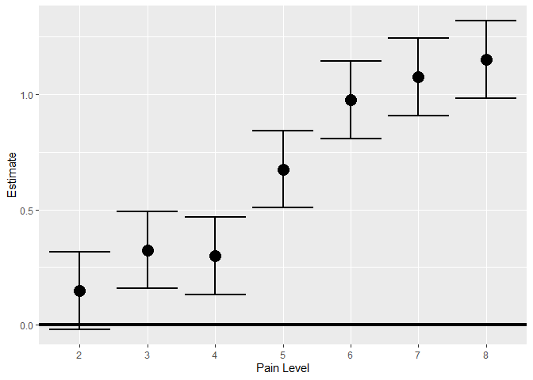

```r
p1 <- ggplot(est1, aes(x = x, y = Estimate)) + geom_point(size = 5) + geom_errorbar(aes(ymax = U, ymin = L),size=1) + geom_hline(yintercept=0, size=1.5, col="black") + xlab("Pain Level")
p1
```

# 6. Ridge regression

**法国经济进口活动有关数据**：因变量为`进口(import)`、`国内生产(DOPROD)`、`股票形式(stock)`和`国内消费(CONSUM)`。

- 样本相关性

```r
data(frencheconomy, package = "brinla")
head(frencheconomy)
```

```
##   YEAR IMPORT DOPROD STOCK CONSUM
## 1   49   15.9  149.3   4.2  108.1
## 2   50   16.4  161.2   4.1  114.8
## 3   51   19.0  171.5   3.1  123.2
## 4   52   19.1  175.5   3.1  126.9
## 5   53   18.8  180.8   1.1  132.1
## 6   54   20.4  190.7   2.2  137.7
```

```r
knitr::kable(round(cor(frencheconomy[,-1]),4), caption = '
    frencheconomy数据', align='c')
```

frencheconomy数据

|  | IMPORT | DOPROD | STOCK | CONSUM |
| --- | --- | --- | --- | --- |
| IMPORT | 1.0000 | 0.9842 | 0.2659 | 0.9848 |
| DOPROD | 0.9842 | 1.0000 | 0.2154 | 0.9989 |
| STOCK | 0.2659 | 0.2154 | 1.0000 | 0.2137 |
| CONSUM | 0.9848 | 0.9989 | 0.2137 | 1.0000 |

- 数据标准化

贝叶斯岭回归假设所有预测因子的系数元素($\beta_1,\dots,\beta_p$)都是从一个标准正态密度中提取的。

```r
fe.scaled <- cbind(frencheconomy[, 1:2], scale(frencheconomy[, c(-1,-2)]))
```

```r
# set priors
n <- nrow(frencheconomy)

fe.scaled$beta1 <- rep(1,n)
fe.scaled$beta2 <- rep(2,n)
fe.scaled$beta3 <- rep(3,n)
```

对于岭回归，参数的先验有一个共同的未知方差，要实现这一点，我们必须使用副本，并改变数据集

```r
# this is the prior for the precision of beta
param.beta = list(prec = list(param = c(1.0e-3, 1.0e-3)))

formula.ridge  = IMPORT ~ f(beta1, DOPROD, model="iid", values = c(1,2,3), hyper = param.beta) + f(beta2, STOCK, copy="beta1", fixed=T) + f(beta3, CONSUM, copy="beta1", fixed=T)
frencheconomy.ridge <- inla(formula.ridge, data=fe.scaled)
ridge.est <- rbind(frencheconomy.ridge$summary.fixed, frencheconomy.ridge$summary.random$beta1[,-1])

knitr::kable(round(ridge.est,4))
```

|  | mean | sd | 0.025quant | 0.5quant | 0.975quant | mode | kld |
| --- | --- | --- | --- | --- | --- | --- | --- |
| (Intercept) | 30.0778 | 0.5198 | 29.0449 | 30.0778 | 31.109 | 30.0778 | 0e+00 |
| 1 | 5.1131 | 5.4237 | -6.7892 | 5.3431 | 15.668 | 5.6205 | 3e-04 |
| 2 | 0.7205 | 0.5451 | -0.3618 | 0.7202 | 1.802 | 0.7199 | 0e+00 |
| 3 | 6.9769 | 5.4265 | -3.5327 | 6.7312 | 18.923 | 6.4159 | 3e-04 |

- Comparing with Standard Bayesian Linear regression

```r
formula <- IMPORT ~  DOPROD + STOCK + CONSUM
frencheconomy.inla <- inla(formula, data = fe.scaled, control.fixed = list(prec = 1.0e-3), control.family = list(hyper = param.beta))
knitr::kable(round(frencheconomy.inla$summary.fixed, 4))
```

|  | mean | sd | 0.025quant | 0.5quant | 0.975quant | mode | kld |
| --- | --- | --- | --- | --- | --- | --- | --- |
| (Intercept) | 30.0778 | 0.5729 | 28.9378 | 30.0778 | 31.216 | 30.0778 | 0 |
| DOPROD | 3.0052 | 10.9358 | -18.5325 | 2.9662 | 24.743 | 2.8961 | 0 |
| STOCK | 0.7197 | 0.6037 | -0.4819 | 0.7198 | 1.919 | 0.7199 | 0 |
| CONSUM | 9.1322 | 10.9315 | -12.6218 | 9.1707 | 30.635 | 9.2416 | 0 |

- Comparing with Ridge regression frequentist approach

```r
reg2 <- lm.ridge(IMPORT ~  DOPROD + STOCK + CONSUM, data = fe.scaled, lambda = seq(0, 1, length=100))

reg2.final <- lm.ridge(IMPORT ~  DOPROD + STOCK + CONSUM, data = fe.scaled, lambda = reg2$kHKB)
reg2.final
```

```
##          DOPROD   STOCK  CONSUM
## 30.0778  4.9560  0.7176  7.1669
```

# 7. Linear regression with autoregressive errors

**时间序列数据**：新西兰的失业数据包括青年(15-19岁)和成人(19岁以上)的季度失业率。

自2008年6月起，新西兰政府废除了《最低工资法》。在此，我们想研究在该法案废除之前和之后，成年人和年轻人失业率之间的关系。

```r
# Read the data
data(nzunemploy, package = "brinla")
nzunemploy$time <- 1:nrow(nzunemploy)
```

绘制成人和青年的时间序列数据

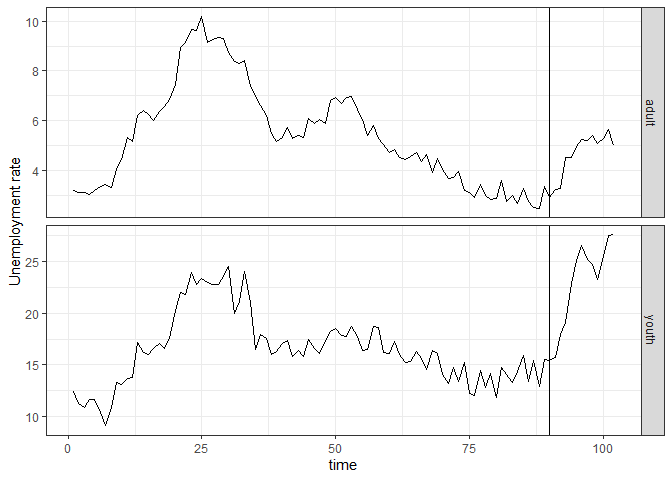

```r
#library(tidyr)
qplot(time, value, data = gather(nzunemploy[,c(2,3,5)], variable, value, -time), geom = "line") + geom_vline(xintercept = 90) + facet_grid(variable ~ ., scale = "free") + ylab("Unemployment rate") + theme_bw()
```

为了使系数更容易理解，我们将成人失业率集中在时间序列的平均值上。

```r
# Centering predictor
nzunemploy$centeredadult = with(nzunemploy, adult - mean(adult))
```

- 拟合一个具有独立误差的标准线性回归

```r
formula1 <- youth ~ centeredadult*policy
nzunemploy.inla1 <- inla(formula1, data= nzunemploy)
# summary(nzunemploy.inla1)
round(nzunemploy.inla1$summary.fixed, 4)
```

```
##                             mean     sd 0.025quant 0.5quant 0.975quant   mode
## (Intercept)               16.282 0.1534     15.980   16.282     16.584 16.282
## centeredadult              1.533 0.0750      1.386    1.533      1.681  1.533
## policyEqual                9.442 0.5258      8.407    9.442     10.475  9.442
## centeredadult:policyEqual  2.853 0.4616      1.945    2.853      3.761  2.853
##                           kld
## (Intercept)                 0
## centeredadult               0
## policyEqual                 0
## centeredadult:policyEqual   0
```

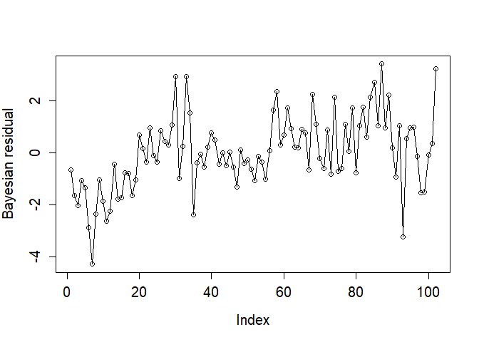

```r
# Plot the Bayesian residuals
par(mfrow=c(1,1))
nzunemploy.res1 <- bri.lmresid.plot(nzunemploy.inla1, type="o")
```

它们之间存在一定程度的自相关。

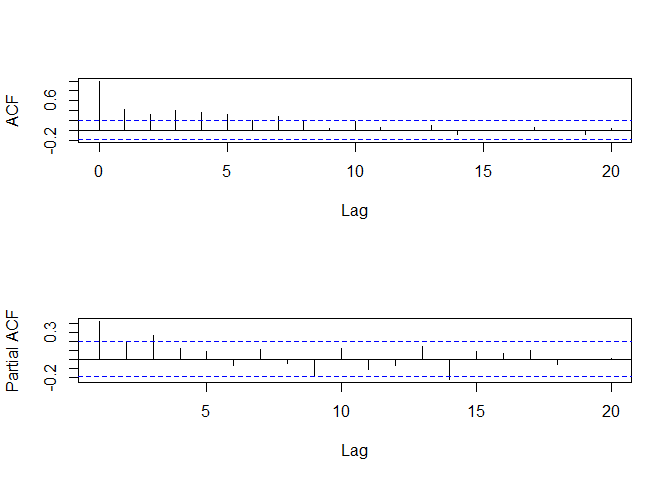

```r
# Plot the autocorrelation and partial autocorrelation
par(mfrow = c(2,1))
acf(nzunemploy.res1$resid, main = "")
acf(nzunemploy.res1$resid, type = "partial", main="")
```

图上的虚线对应95%置信带。自相关函数的形式呈指数衰减，而偏自相关函数的形式在滞后1处有很高的峰值。这些表明AR(1)过程将适合于回归模型中的误差项。

- 拟合一个有AR(1)误差的线性回归

```r
formula2 <- youth ~ centeredadult*policy + f(time, model = "ar1")
nzunemploy.inla2 <- inla(formula2, data = nzunemploy, control.family = list(hyper = list(prec = list(initial = 15, fixed = TRUE))))
# summary(nzunemploy.inla2)
knitr::kable(round(nzunemploy.inla2$summary.fixed, 4))
```

|  | mean | sd | 0.025quant | 0.5quant | 0.975quant | mode | kld |
| --- | --- | --- | --- | --- | --- | --- | --- |
| (Intercept) | 16.344 | 0.3029 | 15.768 | 16.334 | 16.975 | 16.322 | 5e-04 |
| centeredadult | 1.520 | 0.1354 | 1.246 | 1.521 | 1.785 | 1.524 | 1e-04 |
| policyEqual | 8.981 | 0.9724 | 6.876 | 9.036 | 10.746 | 9.117 | 8e-04 |
| centeredadult:policyEqual | 2.516 | 0.6009 | 1.302 | 2.525 | 3.672 | 2.543 | 1e-04 |

```r
knitr::kable(round(nzunemploy.inla2$summary.hyperpar, 4))
```

|  | mean | sd | 0.025quant | 0.5quant | 0.975quant | mode |
| --- | --- | --- | --- | --- | --- | --- |
| Precision for time | 0.4464 | 0.0859 | 0.293 | 0.4420 | 0.6282 | 0.4353 |
| Rho for time | 0.5128 | 0.0898 | 0.329 | 0.5151 | 0.6799 | 0.5163 |

注意，回归模型的精度prec固定在$\tau = \exp(15)$

- 与频率派方法进行比对

```r
#library(nlme)
nzunemploy.gls <- gls(youth ~ centeredadult*policy, correlation = corAR1(form=~1), data = nzunemploy)
summary(nzunemploy.gls)
```

```
## Generalized least squares fit by REML
##   Model: youth ~ centeredadult * policy
##   Data: nzunemploy
##   AIC   BIC logLik
##   353 368.5 -170.5
##
## Correlation Structure: AR(1)
##  Formula: ~1
##  Parameter estimate(s):
##    Phi
## 0.5012
##
## Coefficients:
##                            Value Std.Error t-value p-value
## (Intercept)               16.329    0.2733   59.74       0
## centeredadult              1.522    0.1274   11.94       0
## policyEqual                9.083    0.8614   10.54       0
## centeredadult:policyEqual  2.545    0.5772    4.41       0
##
##  Correlation:
##                           (Intr) cntrdd plcyEq
## centeredadult             -0.020
## policyEqual               -0.318  0.007
## centeredadult:policyEqual -0.067 -0.155  0.583
##
## Standardized residuals:
##     Min      Q1     Med      Q3     Max
## -2.8923 -0.5546 -0.0242  0.5545  2.2957
##
## Residual standard error: 1.505
## Degrees of freedom: 102 total; 98 residual
```

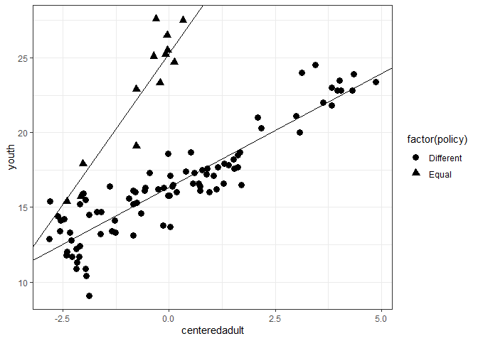

```r
# plot the fitted lines
ggplot(nzunemploy, aes(centeredadult, youth)) + geom_point(aes(shape = factor(policy)), size = 3) + geom_abline(intercept = nzunemploy.inla2$summary.fixed$mean[1], slope = nzunemploy.inla2$summary.fixed$mean[2]) + geom_abline(intercept = nzunemploy.inla2$summary.fixed$mean[1] + nzunemploy.inla2$summary.fixed$mean[3], slope = nzunemploy.inla2$summary.fixed$mean[2] + nzunemploy.inla2$summary.fixed$mean[4]) + theme_bw()
```